# Loneliness of the elderly in London

## Part 1: Data collection

We need to collect data from different websites, I have already done this step and saved them in my computer

```r
#get the shapefiles from London Datastore, choose BFE data, then use qgis
#to merge the 33 shapefiles and get the whole msoa shapefile of london

library(sf)
london_msoa <- st_read(here::here("final_data","2011_london_boundaries","msoa_merge_BFC.shp"))
```

it is imported and in the corrected crs OSGB 1936 let’s plot it to see what it looks like

```r
#plot
library(tmap)
tmap_mode("plot")
```

```
## tmap mode set to plotting
```

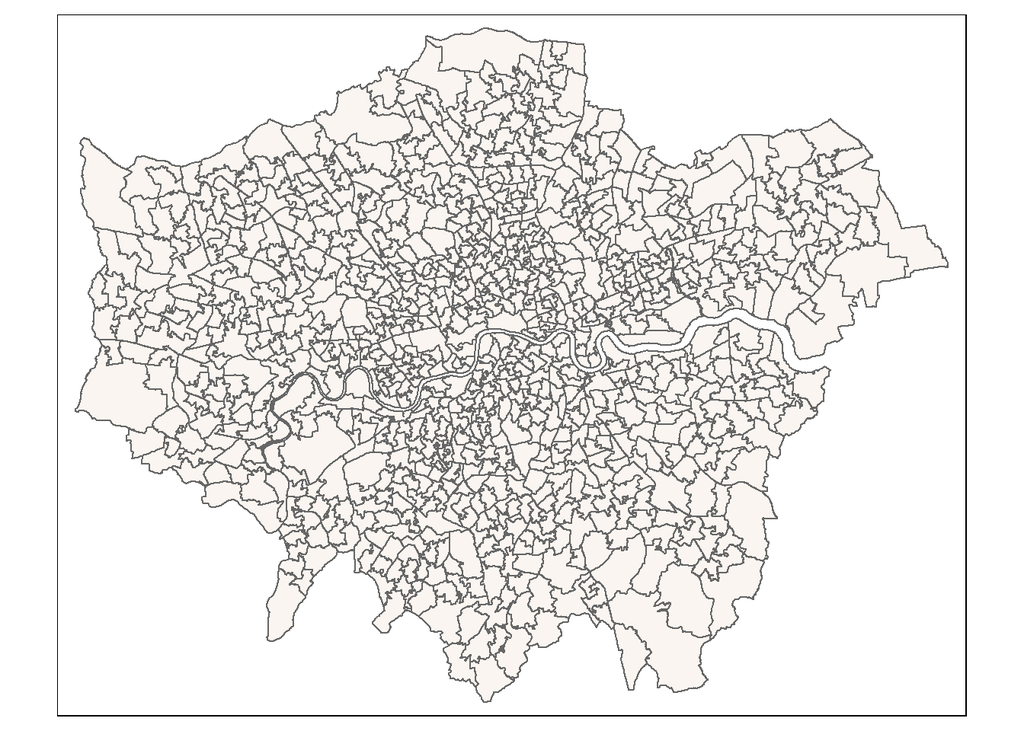

```r
tm_shape(london_msoa) + tm_polygons(col = "antiquewhite2", alpha = 0.3)
```

it looks right, the whole london is ploted by msoa boundaries then we need to get other data, I download these data from London Datastore

```r
#read csv to get the data

house_price <- st_read(here::here("final_data", "land-registry-house-prices-MSOA.csv"))
```

```
## Reading layer `land-registry-house-prices-MSOA' from data source `D:\ucl\moudles\0005GIS\assessment\R\final_data\land-registry-house-prices-MSOA.csv' using driver `CSV'
```

```r
old_loneliness <- st_read(here::here("final_data", "london-loneliness-MSOA.csv"))
```

```
## Reading layer `london-loneliness-MSOA' from data source `D:\ucl\moudles\0005GIS\assessment\R\final_data\london-loneliness-MSOA.csv' using driver `CSV'
```

```r
property_period <- st_read(here::here("final_data", "dwelling-build-period and-property-type-2014-lsoa-msoa.csv"))
```

```
## Reading layer `dwelling-build-period and-property-type-2014-lsoa-msoa' from data source `D:\ucl\moudles\0005GIS\assessment\R\final_data\dwelling-build-period and-property-type-2014-lsoa-msoa.csv' using driver `CSV'
```

```r
bad_health_rent <- st_read(here::here("final_data", "msoa-data.csv"))
```

```
## Reading layer `msoa-data' from data source `D:\ucl\moudles\0005GIS\assessment\R\final_data\msoa-data.csv' using driver `CSV'
```

## Part 2: Data cleaning

Now we have get all the data we need in this analysis, but these datasets contains too much information, I need to filter them to get a simple dataset

```r
#house_price data contains median, mean, and sales of house_price, I choose
#mean figure to do next analysis

library(dplyr)
library(stringr)
house_price_new <- house_price %>%
  filter(house_price$Measure=="Mean", house_price$Year=="Year ending Dec 2011")
house_price_new <- house_price_new[, c("Code", "Value")]
house_price_new$Value <- as.numeric(house_price_new$Value)

old_loneliness_new <- old_loneliness[, c("MSOA.code", "Prevalence")]
old_loneliness_new$Prevalence <- as.numeric(old_loneliness_new$Prevalence)

#I choose property which built after 2000 as new building to see how new buildings influence loneliness of old people because they may prefer old buildings which can provide them with familiar environment
property_period <- property_period %>%
  filter(property_period$Geography2=="MSOA")
property_period$X2000.to.2009 <- as.numeric(property_period$X2000.to.2009)
property_period$X2010.to.2012 <- as.numeric(property_period$X2010.to.2012)
property_period$Total <- as.numeric(property_period$Total)
property_period[is.na(property_period)] = 0
property_period_new <- property_period %>%
  mutate(short_period = (property_period$X2000.to.2009 + property_period$X2010.to.2012) / property_period$Total *100)
property_period_new <- property_period_new[, c("Area.Code3", "short_period")]
property_period_new[is.na(property_period_new)] = 0

#I combine the figures of public rent and private rent to get total rent percentage
rent_percentage <- bad_health_rent[, c("field_1", "field_98", "field_99")]
rent_percentage$field_98 <- as.numeric(rent_percentage$field_98)
rent_percentage$field_99 <- as.numeric(rent_percentage$field_99)
rent_percentage[is.na(rent_percentage)] = 0
rent_percentage <- rent_percentage %>%
  mutate(rent_total = rent_percentage$field_98 + rent_percentage$field_99)
rent_percentage_new <- rent_percentage[, c("field_1", "rent_total")]
rent_percentage_new <- rent_percentage_new %>%
  dplyr::filter(str_detect(field_1, "^E02"))

bad_health <- bad_health_rent[, c("field_1", "field_170")]
bad_health_new <- bad_health %>%
  dplyr::filter(str_detect(field_1, "^E02"))
bad_health_new$field_170 <- as.numeric(bad_health_new$field_170)
colnames(bad_health_new)[2] <- "bad_health_percentage"
```

```r
#now I can remove the intermediate data
rm(bad_health,bad_health_rent,house_price,old_loneliness,property_period,rent_percentage)
```

## Part 3: Visualization

We have got and cleaned all the data we need, however, the data we want to analyze do not have geographical features, so we need to combine it with shapfile of london to do further analysis

```r
#combine data with london shapfile

loneliness_geo <- london_msoa %>%
  left_join(.,
            old_loneliness_new,
            by = c("MSOA11CD" = "MSOA.code"))
loneliness_geo <- loneliness_geo %>%
  left_join(.,
            bad_health_new,
            by = c("MSOA11CD" = "field_1"))
loneliness_geo <-loneliness_geo %>%
  left_join(.,
            house_price_new,
            by = c("MSOA11CD" = "Code"))
loneliness_geo <- loneliness_geo%>%
  left_join(.,
            property_period_new,
            by = c("MSOA11CD" = "Area.Code3"))
loneliness_geo <- loneliness_geo %>%
  left_join(.,
            rent_percentage_new,
            by = c("MSOA11CD" = "field_1"))
```

let’s plot it to see the distribution of loneliness,since the file is too large, I will use “plot”mode in the next code, if you want to see the interative map, you can change tmap_mode to “view”

```r
tmap_mode("plot")
```

```
## tmap mode set to plotting
```

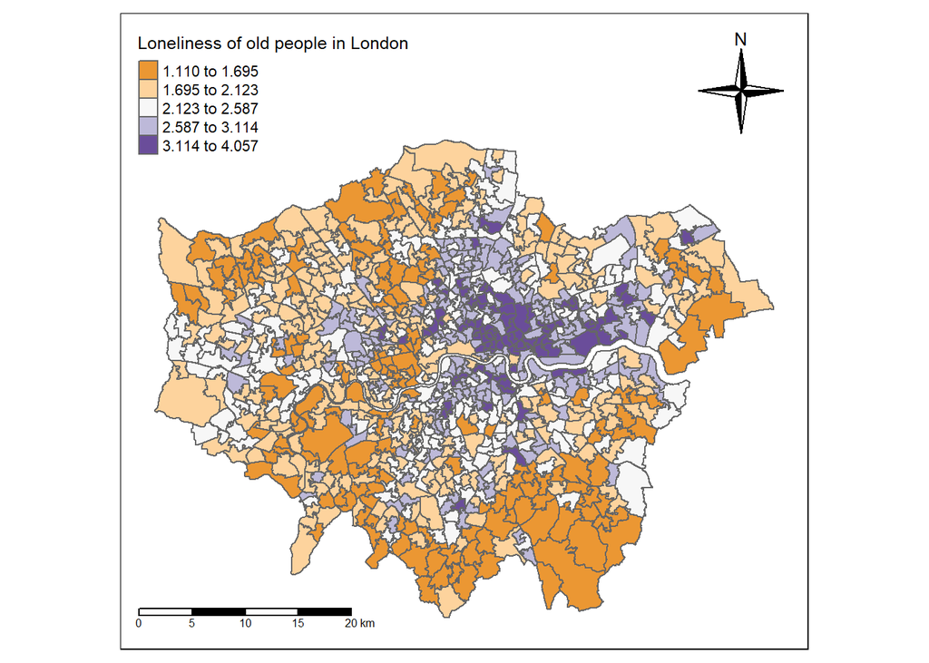

```r
tm_shape(loneliness_geo) +
  tm_compass(type = "4star", position=c("right", "top")) +
  tm_borders(col = "gray40", lwd = 1) +
  tm_scale_bar(position=c("left", "bottom")) +
  tm_layout(inner.margins=c(.05,.05,.2,.05))+
  tm_polygons("Prevalence",
              style = "jenks",
              palette="PuOr",
              midpoint=NA,
              popup.vars=c("MSOA11CD", "Prevalence"),
              title="Loneliness of old people in London")
```

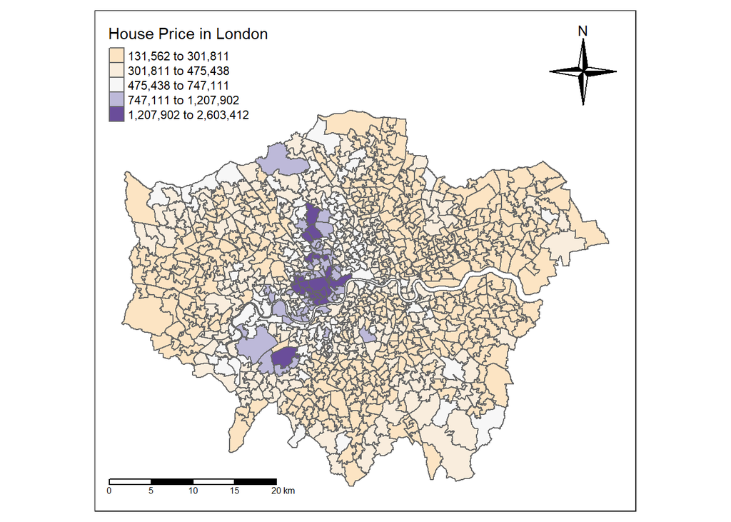

```r
#then is the data of house price.

tm_shape(loneliness_geo) +
  tm_compass(type = "4star", position=c("right", "top")) +
  tm_borders(col = "gray40", lwd = 1) +
  tm_scale_bar(position=c("left", "bottom")) +
  tm_layout(inner.margins=c(.05,.05,.2,.05))+
  tm_polygons("Value",
              style = "jenks",
              palette="PuOr",
              midpoint=NA,
              popup.vars=c("MSOA11CD", "Value"),
              title="House Price in London")
```

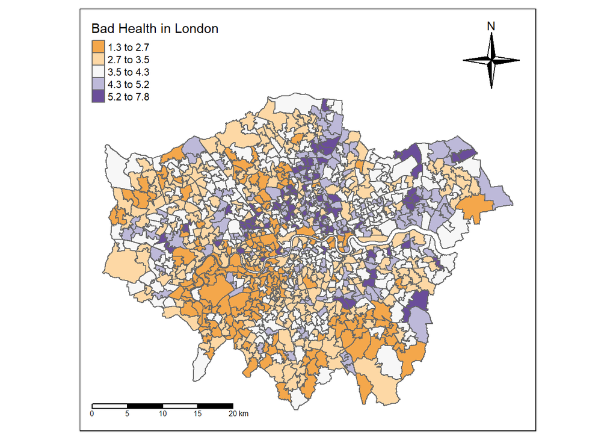

```r
#then is the data of bad health

tm_shape(loneliness_geo) +
  tm_compass(type = "4star", position=c("right", "top")) +
  tm_borders(col = "gray40", lwd = 1) +
  tm_scale_bar(position=c("left", "bottom")) +
  tm_layout(inner.margins=c(.05,.05,.2,.05))+
  tm_polygons("bad_health_percentage",
              style = "jenks",
              palette="PuOr",
              midpoint=NA,
              popup.vars=c("MSOA11CD", "bad_health_percentage"),
              title="Bad Health in London")
```

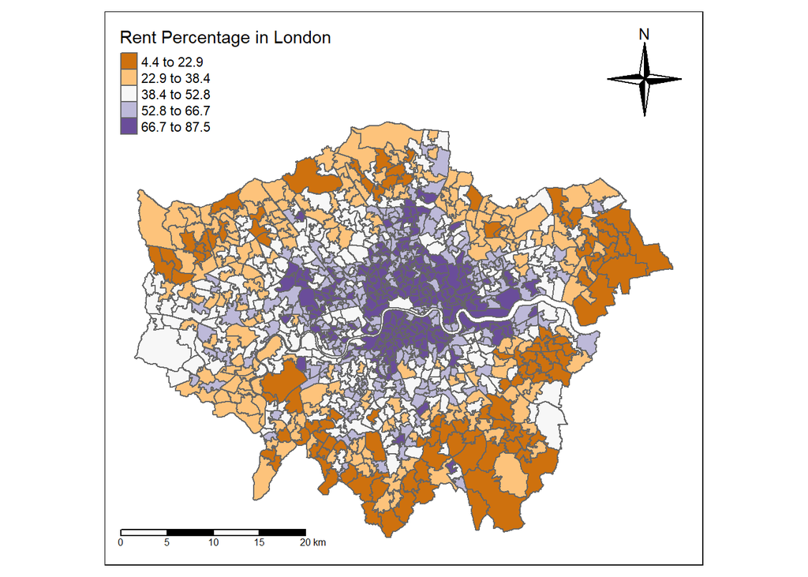

```r
#then is the data of rent percentage

tm_shape(loneliness_geo) +
  tm_compass(type = "4star", position=c("right", "top")) +
  tm_borders(col = "gray40", lwd = 1) +
  tm_scale_bar(position=c("left", "bottom")) +
  tm_layout(inner.margins=c(.05,.05,.2,.05))+
  tm_polygons("rent_total",
              style = "jenks",
              palette="PuOr",
              midpoint=NA,
              popup.vars=c("MSOA11CD", "rent_total"),
              title="Rent Percentage in London")
```

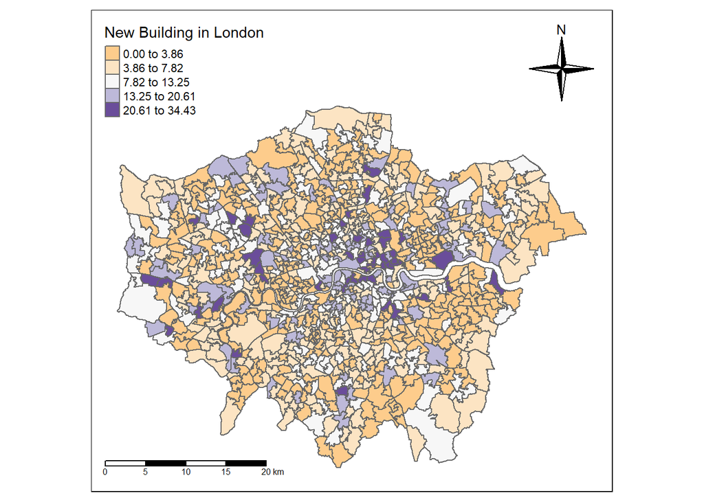

```r
#finally the data of new building

tm_shape(loneliness_geo) +
  tm_compass(type = "4star", position=c("right", "top")) +
  tm_borders(col = "gray40", lwd = 1) +
  tm_scale_bar(position=c("left", "bottom")) +
  tm_layout(inner.margins=c(.05,.05,.2,.05))+
  tm_polygons("short_period",
              style = "jenks",
              palette="PuOr",
              midpoint=NA,
              popup.vars=c("MSOA11CD", "short_period"),
              title="New Building in London")
```

## Part 4: Correlation analysis

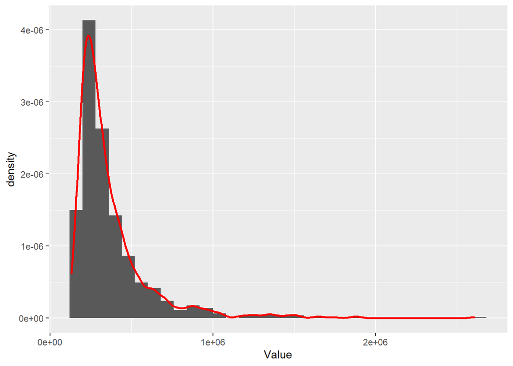

```r
# let's do regression analysis to the data
#from the maps we can see that the distribution of house price is particularly concentrated, so I did a log transformation to it to conduct following analysis, it can be seen that after log transformation it is more normally distributed.

library(ggplot2)
library(tidyverse)
ggplot(loneliness_geo, aes(x=Value)) +
  geom_histogram(aes(y = ..density..),
                 binwidth = 80000) +
  geom_density(colour="red",
               size=1,
               adjust=1)
```

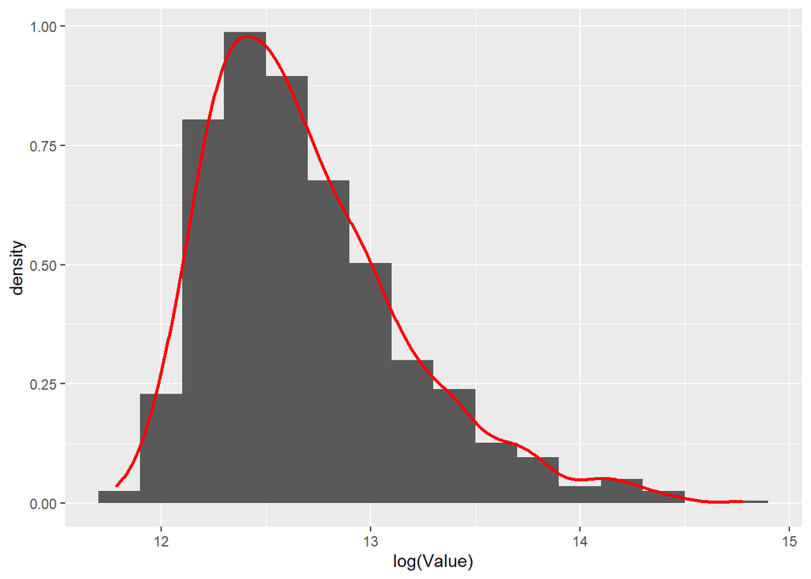

```r
ggplot(loneliness_geo, aes(x=log(Value))) +
  geom_histogram(aes(y = ..density..),
                 binwidth = 0.2) +
  geom_density(colour="red",
               size=1,
               adjust=1)
```

```r
library(tidypredict)
library(car)
y = loneliness_geo$Prevalence
x1 = loneliness_geo$Value
x2 = loneliness_geo$bad_health_percentage
x3 = loneliness_geo$rent_total
x4 = loneliness_geo$short_period

model_final <- lm(y ~ log(x1) + x2 +x3 +x4, data = loneliness_geo)
tidy(model_final)
```

```
## # A tibble: 5 x 5
##   term        estimate std.error statistic   p.value
##   <chr>          <dbl>     <dbl>     <dbl>     <dbl>
## 1 (Intercept)  5.90     0.251        23.5  2.07e- 97
## 2 log(x1)     -0.402    0.0186      -21.6  4.88e- 85
## 3 x2           0.138    0.0102       13.4  6.25e- 38
## 4 x3           0.0190   0.000510     37.2  1.21e-189
## 5 x4           0.00511  0.00132       3.87 1.16e-  4
```

```r
summary(model_final)
```

```
##
## Call:
## lm(formula = y ~ log(x1) + x2 + x3 + x4, data = loneliness_geo)
##
## Residuals:
##      Min       1Q   Median       3Q      Max
## -0.84326 -0.15307  0.00257  0.14598  1.01139
##
## Coefficients:
##               Estimate Std. Error t value Pr(>|t|)
## (Intercept)  5.8984617  0.2506088  23.537  < 2e-16 ***
## log(x1)     -0.4017872  0.0185840 -21.620  < 2e-16 ***
## x2           0.1376298  0.0102376  13.444  < 2e-16 ***
## x3           0.0189751  0.0005097  37.229  < 2e-16 ***
## x4           0.0051062  0.0013191   3.871 0.000116 ***
## ---
## Signif. codes:  0 '***' 0.001 '**' 0.01 '*' 0.05 '.' 0.1 ' ' 1
##
## Residual standard error: 0.2421 on 978 degrees of freedom
## Multiple R-squared:  0.8253, Adjusted R-squared:  0.8246
## F-statistic:  1155 on 4 and 978 DF,  p-value: < 2.2e-16
```

```r
vif(model_final)
```

```
##  log(x1)       x2       x3       x4
## 1.333001 1.777302 1.591258 1.145902
```

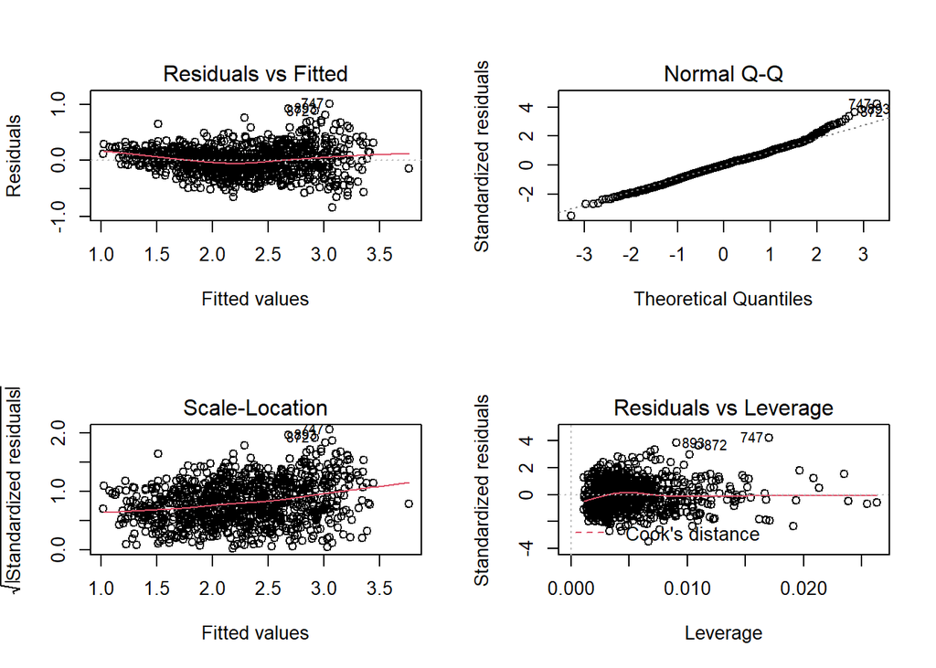

```r
#let's see the residuals of our model
loneliness_reg <- loneliness_geo %>%
  mutate(model_final_res = residuals(model_final))

par(mfrow=c(2,2))
plot(model_final)
```

we now get the correlation of these variables, the R square is high enough to support the assumption that there are relationships exist between these variables, but since this analysis is based on geography, we need to consider the influence of space.

```r
library(spgwr)
st_crs(loneliness_geo) = 27700
loneliness_geo_sp <-loneliness_geo %>%
  as(., "Spatial")
coordsW <- loneliness_geo %>%
  st_centroid() %>%
  st_geometry()
st_crs(coordsW) = 27700
coordsWSP <- coordsW %>%
  as(., "Spatial")
coordsWSP
```

```
## class       : SpatialPoints
## features    : 983
## extent      : 505153.2, 559068.7, 157495.8, 199515.6  (xmin, xmax, ymin, ymax)
## crs         : +proj=tmerc +lat_0=49 +lon_0=-2 +k=0.9996012717 +x_0=400000 +y_0=-100000 +ellps=airy +units=m +no_defs
```

```r
GWRbandwidth <- gwr.sel(Prevalence ~ log(Value) + rent_total +bad_health_percentage +short_period,
                  data = loneliness_geo_sp,
                        coords=coordsWSP,
                        adapt=T)
```

```
## Adaptive q: 0.381966 CV score: 54.41877
## Adaptive q: 0.618034 CV score: 55.79349
## Adaptive q: 0.236068 CV score: 52.84369
## Adaptive q: 0.145898 CV score: 51.07124
## Adaptive q: 0.09016994 CV score: 49.1236
## Adaptive q: 0.05572809 CV score: 47.16341
## Adaptive q: 0.03444185 CV score: 45.55033
## Adaptive q: 0.02128624 CV score: 44.70596
## Adaptive q: 0.01315562 CV score: 44.92716
## Adaptive q: 0.02038935 CV score: 44.67937
## Adaptive q: 0.01895174 CV score: 44.62724
## Adaptive q: 0.01673782 CV score: 44.5751
## Adaptive q: 0.01446248 CV score: 44.67946
## Adaptive q: 0.01586872 CV score: 44.60512
## Adaptive q: 0.01721991 CV score: 44.58188
## Adaptive q: 0.01678334 CV score: 44.5751
## Adaptive q: 0.01682403 CV score: 44.57522
## Adaptive q: 0.01678334 CV score: 44.5751
```

```r
#run the gwr model

gwr.model = gwr(Prevalence ~ log(Value) + rent_total +bad_health_percentage +short_period,
                  data = loneliness_geo_sp,
                coords=coordsWSP,
                adapt=GWRbandwidth,
                hatmatrix=TRUE,
                se.fit=TRUE)
gwr.model
```

```
## Call:
## gwr(formula = Prevalence ~ log(Value) + rent_total + bad_health_percentage +
##     short_period, data = loneliness_geo_sp, coords = coordsWSP,
##     adapt = GWRbandwidth, hatmatrix = TRUE, se.fit = TRUE)
## Kernel function: gwr.Gauss
## Adaptive quantile: 0.01678334 (about 16 of 983 data points)
## Summary of GWR coefficient estimates at data points:
##                             Min.    1st Qu.     Median    3rd Qu.       Max.
## X.Intercept.           1.4642156  3.9070857  4.9600568  6.6758203 12.0056838
## log.Value.            -0.8712892 -0.4548885 -0.3299531 -0.2470980 -0.0693551
## rent_total             0.0078097  0.0143734  0.0168295  0.0189647  0.0231976
## bad_health_percentage  0.0616923  0.1345076  0.1574946  0.1873681  0.3197894
## short_period          -0.0158138 -0.0010761  0.0049388  0.0084150  0.0216510
##                        Global
## X.Intercept.           5.8985
## log.Value.            -0.4018
## rent_total             0.0190
## bad_health_percentage  0.1376
## short_period           0.0051
## Number of data points: 983
## Effective number of parameters (residual: 2traceS - traceS'S): 164.2811
## Effective degrees of freedom (residual: 2traceS - traceS'S): 818.7189
## Sigma (residual: 2traceS - traceS'S): 0.2054174
## Effective number of parameters (model: traceS): 114.8241
## Effective degrees of freedom (model: traceS): 868.1759
## Sigma (model: traceS): 0.1994806
## Sigma (ML): 0.1874683
## AICc (GWR p. 61, eq 2.33; p. 96, eq. 4.21): -238.8455
## AIC (GWR p. 96, eq. 4.22): -386.9127
## Residual sum of squares: 34.54691
## Quasi-global R2: 0.8947505
```

```r
results <- as.data.frame(gwr.model$SDF)
names(results)
```

```
##  [1] "sum.w"                        "X.Intercept."
##  [3] "log.Value."                   "rent_total"
##  [5] "bad_health_percentage"        "short_period"
##  [7] "X.Intercept._se"              "log.Value._se"
##  [9] "rent_total_se"                "bad_health_percentage_se"
## [11] "short_period_se"              "gwr.e"
## [13] "pred"                         "pred.se"
## [15] "localR2"                      "X.Intercept._se_EDF"
## [17] "log.Value._se_EDF"            "rent_total_se_EDF"
## [19] "bad_health_percentage_se_EDF" "short_period_se_EDF"
## [21] "pred.se.1"
```

```r
loneliness_geo2 <- loneliness_geo %>%
  mutate(coefhouseprice = results$log.Value.,
         coefbadhealth = results$bad_health_percentage,
         coefrent = results$rent_total,
         coefnewbuilding = results$short_period)
```

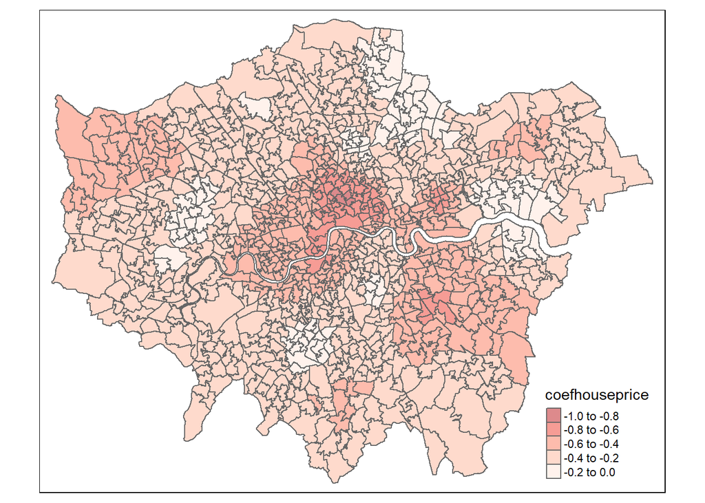

```r
tm_shape(loneliness_geo2) +
  tm_polygons(col = "coefhouseprice",
              palette = "Reds",
              alpha = 0.5)
```

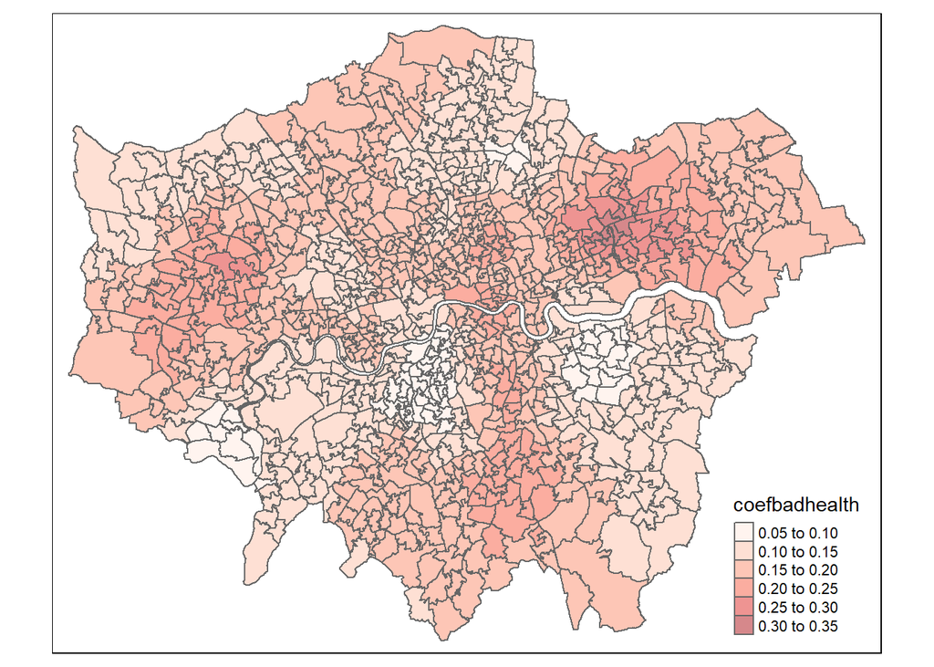

```r
tm_shape(loneliness_geo2) +
  tm_polygons(col = "coefbadhealth",
              palette = "Reds",
              alpha = 0.5)
```

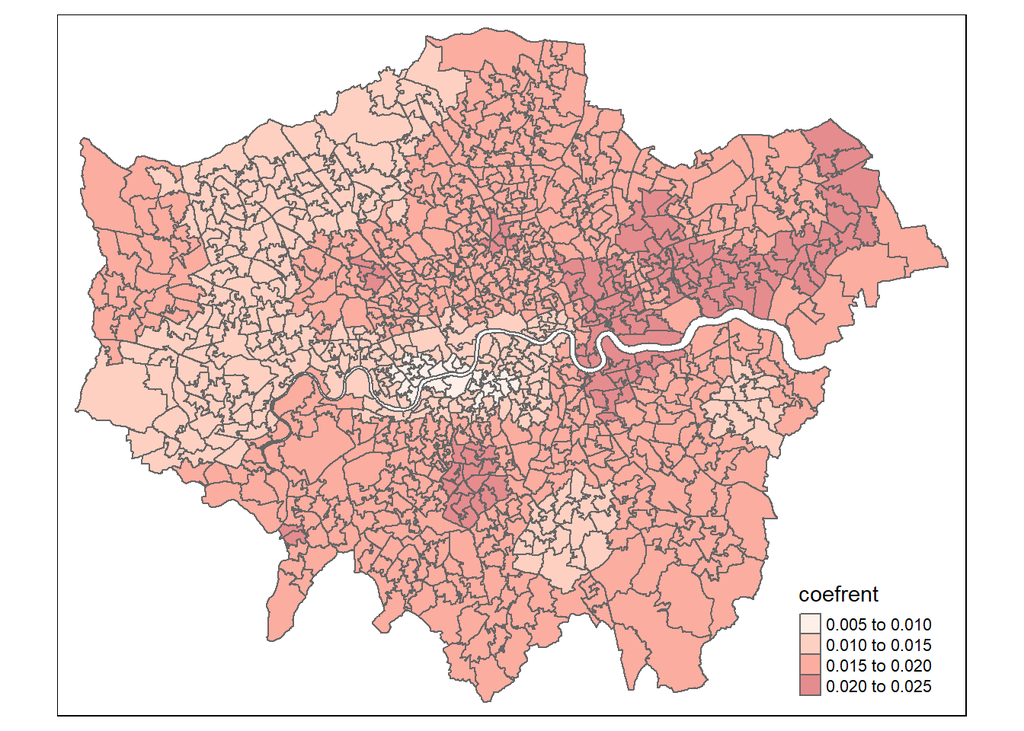

```r
tm_shape(loneliness_geo2) +
  tm_polygons(col = "coefrent",
              palette = "Reds",
              alpha = 0.5)
```

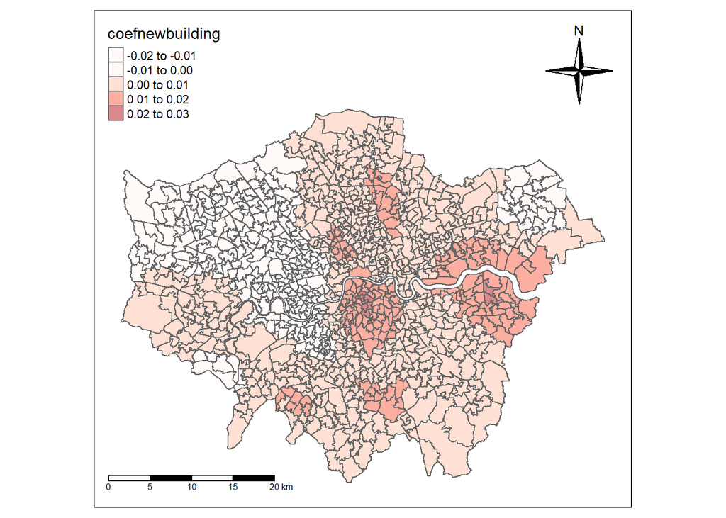

```r
tm_shape(loneliness_geo2) +
  tm_compass(type = "4star", position=c("right", "top")) +
  tm_borders(col = "gray40", lwd = 1) +
  tm_scale_bar(position=c("left", "bottom")) +
  tm_layout(inner.margins=c(.05,.05,.2,.05))+
  tm_polygons(col = "coefnewbuilding",
              palette = "Reds",
              alpha = 0.5)
```